# How firm communication affects the impact of layoff announcements on brand strength over time

Converted from PDF `Stabler-LayoffCommunicationBrandStrength-2023-IJRM.pdf` · 24 pages · anchors: page `#pN`, block `#pN-bK`

Page 1

### How firm communication affects the impact of layoff announcements on brand strength over time

### Samuel Stäbler <sup>a</sup>, Alexander Himme <sup>b</sup><sup>,</sup><sup>⇑</sup>, Alexander Edeling <sup>c</sup>, Max Backhaus <sup>d</sup>

a Department for Marketing, Tilburg University, Netherlands b Management Accounting, Kühne Logistics University, Großer Grasbrook 17, 20457 Hamburg, Germany c Department of Marketing, KU Leuven, Belgium d Customer Management, OBI, Germany

a r t i c l e i n f o

Article history: First received on 16 December 2020 and was under review for 11 months Available online 9 June 2023

Area Editor: Alina Sorescu Accepted editor: Renana Peres

Keywords: Downsizing Layoff announcements Brand image Advertising Corporate social responsibility Public relations Social media Communication mix Error correction model

a b s t r a c t

Firms usually undertake layoffs to improve financial performance. However, layoffs often have negative effects on various stakeholders, including consumers. In this paper, we examine the magnitude and duration of the potential negative effect of layoff announcements on brand strength. We also examine how a firm’s communication accompanying a layoff can potentially counteract the observed negative effect of layoff announcements on brand strength. We compare how advertising communication intensity, social media communication (i.e., brand-initiated tweets), public relation (PR) communication, and communication of CSR initiatives moderate the main effect of layoff announcements on brand strength. Using an error correction model and drawing on 366 announcements of layoff events in Germany, this study identifies the magnitude and duration of the main effect. An examination of five years of weekly consumer brand perception data across multiple industries and domestic and foreign firms shows that advertising communication intensity and social media communication amplify the negative impact of layoff announcements on brand strength. Conversely, PR communication and communication of CSR initiatives help mitigate the negative effect. These findings provide guidance on the best way for firms to design firm communication in the context of layoff announcements.

2023 Elsevier B.V. All rights reserved.

1. Introduction

Layoff announcements appear regularly in leading business and public media and are particularly prevalent during economic crises, such as the financial crisis of 2008–2009 or the COVID-19 crisis beginning in 2020. For instance, in November 2020, IBM announced the elimination of approximately 10,000 jobs in Europe (Bloomberg 2020). Travel disruptions caused by the coronavirus forced the travel firm TUI and the German airline Lufthansa to cut 8,000 jobs and 22,000 jobs, respectively, worldwide (Euronews 2020). Even in the previously booming tech industry, companies laid off approximately 160,000 employees worldwide in 2022 and already roughly 157,000 people within the first three months of 2023 (Layoffs.fyi 2023).

https://doi.org/10.1016/j.ijresmar.2023.06.002 0167-8116/ 2023 Elsevier B.V. All rights reserved.

⇑Corresponding author.

E-mail addresses: S.Staebler@tilburguniversity.edu (S. Stäbler), alexander.himme@the-klu.org (A. Himme), alexander.edeling@kuleuven.be (A. Edeling), max.backhaus@obi.de (M. Backhaus).

[figure not shown]

NOTE: figure/graphic rendered as an image from the PDF; its content is not machine-readable text. Caption (if any) follows as the next block.

International Journal of Research in Marketing 40 (2023) 700–723

International Journal of Research in Marketing

Page 2

Layoff researchers suggest that downsizing events are a ‘‘triumph of short-termism” (Bidwell & Cappelli 2016) that sometimes have long-term detrimental effects (Sucher & Gupta 2018). Extant research shows that these negative impacts relate to stakeholders directly affected by the layoff such as employees who lose jobs, customers who experience product quality reductions, and shareholders whose stock prices decline (e.g., Datta et al. 2010; Habel & Klarmann 2015; Homburg et al. 2012; Love & Kraatz 2009). Anecdotal evidence suggests that the brand perception of seemingly unaffected consumers deteriorates, too. One example is the former cell phone market leader Nokia, whose downsizing activities in Bochum (Germany) in January 2008 (New York Times 2008) triggered a loss in YouGov’s brand strength<sup>1</sup> measure from 46 to 1 (on a scale from 100 to + 100) within half a year. Firms are eager to understand how to maintain their brand strength, and which managerially actionable factors influence their stakeholders’ perceptions during layoffs. However, previous research on layoffs has focused almost exclusively on moderating factors relating to strategy, governance, and HR policies (Datta et al. 2010). Little of this was useful to marketing managers who need to know how to mitigate the harm to the company’s brand. Against this background, our study attempts to answer the following research questions:

1. How do corporate layoff announcements affect consumer brand strength over time? 2. How do different types of firm communication moderate the focal relationship between corporate layoff announcements and brand strength?

We focus on the effects of layoffs on cumulative brand strength over time because managers are interested in the lasting detrimental effects of communicated layoff plans to make better-informed decisions about cutting the workforce (e.g., Sucher & Gupta 2018). In addition, brand strength is a ‘‘sticky” construct that does not change rapidly (Edeling & Fischer 2016; Hanssens et al. 2014), so a consequential impact should be observable only after consumers have been able to fully process the new information and to form new associations in their memory.

Parallel to the communication of a layoff, firms constantly send other messages to consumers, investors, and other stakeholders through various forms of communication. Consequently, the impact of layoff announcements on brand strength may also depend on different types of firm communication activities surrounding the layoff. We compare how advertising communication intensity, social media communication via brand-initiated tweets, public relation (PR) communication, and communication of corporate social responsibility (CSR) initiatives moderate the main effect of layoff announcements on brand strength. For example, it is not clear how advertising communication intensity impacts brand strength in times of layoffs. Since layoff announcements create consumer uncertainty about product quality (e.g., Habel & Klarmann 2015), consumers may rely more heavily on the firm’s advertising as a source of information that might mitigate the uncertainty and the negative effect on brand strength. On the opposite, consumers know that advertising is costly, and layoff announcements signal cost-cutting activities with detrimental effects for employees. Concurrent advertising communication intensity and layoff announcements may arouse consumers’ distrust and thus amplify the negative effect on brand strength.

To gain insights into how layoff announcements and accompanying firm communications affect brand strength, we analyzed 366 layoff announcements of 82 firms from durable goods, nondurable goods, services and retailing industries from 2008 to 2012 as well as weekly brand strength data. Using an error correction model, we identify significantly negative cumulative effects of layoff announcements on brand strength over time. On average, brands needed seven weeks to recover from a layoff announcement. Overall, a firm’s advertising communication intensity and social media communication via brand-initiated tweets amplify the negative effects, while communications of CSR initiatives and PR communication attenuate the detrimental brand strength consequences.

Our findings contribute to the marketing-related research of layoff announcement effects in several ways. First, previous research has examined the impact of corporate layoffs on metrics such as customer satisfaction (e.g., Habel & Klarmann 2015) or sales (Landsman & Stremersch 2020). We investigate the influence of layoffs on brand strength, which represents a core element of customer-based brand equity (Keller 1993). Second, our weekly brand strength data allow us to determine the cumulative impact of layoff announcements on brand strength over time. Third, to the best of our knowledge, this is the first study to analyze the moderating impact of different facets of firm communication on consumer reactions to layoff announcements. These findings should help marketing strategists better manage the impact of layoff announcements on their brand.

2. Literature review

Our study is distinct from the literature stream on marketing-related firm crises (Khamitov et al. 2020), such as productharm events (e.g., Cleeren et al. 2013), service failures (e.g., Gijsenberg et al. 2015) and more general brand transgressions such as the violation of ethical norms (Stäbler & Fischer 2020). Although these events may also call into question the merit of the firm’s prior actions and its prospects, the results of this research cannot simply be transferred to a layoff announcement

1 Brand strength covers several image and performance dimensions of a brand as perceived by consumers (Fischer et al. 2010; Keller 1993; Keller 2008). Brand strength as we use it within this study encompasses brand quality, brand value, brand satisfaction, brand recommendation, brand identification, and overall brand impression.

S. Stäbler, A. Himme, A. Edeling et al. International Journal of Research in Marketing 40 (2023) 700–723

701

Page 3

for several reasons. (1) Different information content regarding product quality and firm performance are read into a layoff announcement. A product-harm crisis, for example, signals a loss in product quality that may directly influence consumer consumption, whereas layoff announcements do not directly affect consumers’ utility. (2) Unlike most crises, which require firms to react spontaneously, layoffs represent a firm’s planned decision, allowing firms some level of control over timing and communication, possibly permitting containment of potentially negative effects (Landsman & Stremersch 2020). (3) Layoffs have a clear goal: future cost reduction and improvement of firm performance. Conversely, product-harm crises and violations of ethical norms may be a result of past cost-reduction actions.

Table 1 provides an overview of existing marketing-related research in the context of layoff announcements. In general, these studies show negative effects on financial (e.g., sales or idiosyncratic risk) and non-financial (e.g., customer satisfaction) metrics (see Column 4 of Table 1). Our study extends this body of research in various dimensions.

First, we examine the impact of layoff announcements on brand strength. While Landsman and Stremersch (2020) refer to brand strength effects in their conceptual foundation, they do not investigate the effects empirically. Consequently, they suggest that it is worthwhile for future research to measure customer mindset effects in more detail. Subramony & Holtom (2012) measure customer evaluation for a temporary help service company characterized by voluntary employee turnover and downsizing. Unlike our study, their study refers to one company only and does not consider any cumulative effects over time.

Second, prior studies analyze firm-related (e.g., firm size) and layoff-related (e.g., layoff size) moderators of the main effects. We extend prior research that largely neglects the moderating impact of the marketing mix on consumer reactions to layoff announcements by incorporating our analysis of four important ways firms communicate with their stakeholders (Column 7).

Third, our study extends the scope of previously used data samples. In fact, existing research has strongly emphasized B2B firms and has relied on rather small sample sizes (Column 2 and Column 3 of Table 1). Furthermore, existing research has mostly used yearly data (Column 5 of Table 1) such as the American Customer Satisfaction Index (ACSI). By contrast, we use a large sample and investigate consumer responses for B2C companies on a week-to-week basis. This data level offers us the possibility to derive the cumulative effect over time and its total duration (Column 6).

Finally, we would also like to note that the results of the existing literature on the impact of layoffs cannot simply be transferred to brand strength effects. For example, the extant body of literature argues that customer satisfaction often declines following a layoff because customers lose their contact persons in companies (e.g., Habel and Klarmann 2015). In contrast, brand strength has a product-focus and does not require an existing customer relationship (unlike customer satisfaction). Results for corporate reputation (e.g., Love and Kraatz 2009) are also not transferrable to brand strength. Corporate reputation is an aggregate construct with a general firm focus that refers to company goodwill (Ettenson and Knowles 2008; Himme and Fischer 2014). It includes components such as corporate governance and the quality of management (e.g., Fombrun and Shanley 1990). This is also reflected by the operationalization of corporate reputation in these studies by yearly data via Fortune’s America’s Most Admired Companies (AMAC) database.

3. Conceptual framework and hypotheses

3.1. General overview of the main elements of the framework

Fig. 1 depicts our conceptual framework. We define layoffs as the permanent removal of a significant number of employees from the payroll of an organization (e.g., Freeman & Cameron 1993). If the business and public media communicate about a planned or conducted downsizing initiative that includes laying off part of the workforce, we call this event a layoff announcement.

Brand strength is our focal outcome variable, for which we derive the first hypothesis that layoff announcements negatively influence cumulative brand strength. We focus our theoretical hypotheses on brand strength effects. However, given that consumers need to be aware of a layoff announcement in order to negatively consider it in their decision-making process, we empirically test via several pre-studies whether layoff announcements increase brand awareness (see Section 4 below).

Managers face a wide choice of communication forms with their stakeholders (e.g., Dijkstra et al. 2005; Keller 2008). We analyze how advertising communication intensity, social media communication (i.e., brand-initiated tweets), PR communication, and communication of CSR initiatives could potentially moderate the hypothesized negative relationship between layoff announcements and brand strength. We emphasize these forms of firm communication because we believe they offer the most direct instruments for mitigating the potential adverse effects of layoff announcements. These forms of communication reflect different possibilities by which the firm can establish a dialogue and build relationships with their customers and other stakeholders (Keller 2001; Kotler & Keller 2015). Subsequently, we define the four forms of firm communication.

Advertising communication intensity refers to the brand’s industry share of any paid form of nonpersonal presentation and promotion of products via print, broadcast, network, and display media (Kotler & Keller 2015). Social media communication in our case refers to brand-initiated tweets designed to engage consumers or prospects and directly or indirectly raise awareness, improve image, or elicit sales (Kotler & Keller 2015). Public relation (PR) communication in general includes a variety of firm announcements directed to consumers, other firms, the government, and the media to promote a company’s image or

S. Stäbler, A. Himme, A. Edeling et al. International Journal of Research in Marketing 40 (2023) 700–723

702

Page 4

Table 1

Marketing studies on outcomes of layoff announcements.

Reference Industry Layoff data source and sample

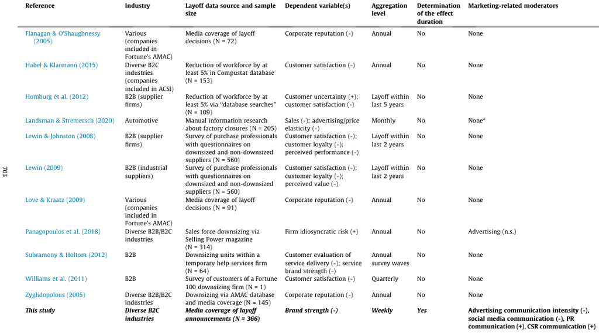

NOTE: complex table shown as an image of the PDF; the text below is a rough machine extraction and may be mis-aligned.

Notes: AMAC: America’s Most Admired Companies; ACSI: American Customer Satisfaction Index; B2B: business-to-business; B2C: business-to-consumer; +: positive effect; -: negative effect; n.s.: insignificant

effect. a In this study, advertising is included as the dependent variable ‘‘advertising elasticity” and not modeled as a moderator.

S. Stäbler, A. Himme, A. Edeling et al. International Journal of Research in Marketing 40 (2023) 700–723

703

Page 5

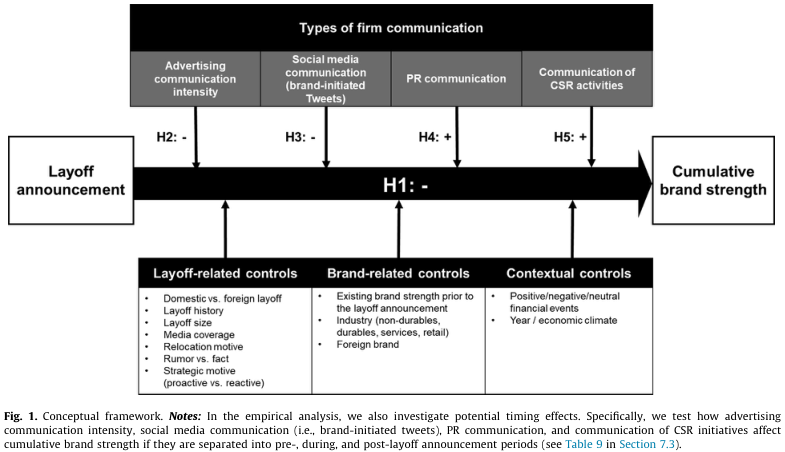

NOTE: figure/graphic rendered as an image from the PDF; its content is not machine-readable text. Caption (if any) follows as the next block.

its individual product communications (e.g., Kotler & Mindak 1978). Given the large and broad number of press releases, we focus on press releases that relate to the marketing mix (e.g., a new product introduction, changes in price policy, etc.). Finally, communication of corporate social responsibility (CSR) initiatives encompasses identified communication of company-sponsored cause events, activities, and programs (e.g., Kotler & Keller 2015).

We derive control variables from the accounting/finance (e.g., Chen et al. 2001) and marketing literature (e.g., Landsman & Stremersch 2020) and distinguish among layoff-related, brand-related, and contextual control variables.

3.2. Main effect of layoff announcements on cumulative brand strength

Several theories suggest that layoff announcements may have a negative impact on brand strength over time (i.e., cumulative brand strength). First, the balance theory of attitude change suggests that a person is motivated to maintain balance in his or her relationship with another individual or object (Heider 1958). Individuals seek to preserve attitudinal consistency with each other. Thus, when an individual no longer shares the same attitudes or values as another individual or object, the relationship falls out of balance (Anaza et al. 2021). To achieve attitudinal consistency, individuals consider the decency of firm transactions they observe, even if a transaction does not directly affect them (e.g., Kahneman et al. 1986). Layoff announcements represent transactions that may be interpreted as a violation of fairness standards and an abandonment of stakeholders who deserve support (e.g., Landsman & Stremersch 2020; Love & Kraatz 2009; Pavlou & Gefen 2005). Thus, such layoff announcements may lead to imbalance between the brand perception and the actions of the brand because they potentially reflect an undesired attitude on the side of the brand (i.e., unfairness). To reestablish balance, the individual must adjust his or her attitude with a more negative perception of brand strength.

Second, social relationship theory suggests that individuals build relationships with brands in a manner similar to how they form relationships with other people in a social context (Aggarwal 2004). Such relationships carry with them norms of behavior that guide individuals’ evaluations of their relationship partner. In the context of layoff announcements, we can conclude that when individuals form relationships with brands that mirror their social relationships, norms of social relationships are used as guiding principles in their interactions with brands. When brands behave like socialized members of a culture, they are evaluated by the rules that govern the society and must act in line with these rules (e.g., Bhattacharya & Sen 2003). Although layoffs may be legally harmless, individuals may perceive layoffs as a violation of a brand’s relationship with its employees (De Meuse et al. 2004). This perceived misconduct may disturb the relationship between the brand and individuals, negatively affecting brand strength.

Third, from an information economics perspective, products can be classified into three categories—search, experience, and credence goods—that reflect the individual’s ability to assess product quality before actual use (Darby & Karni 1973). For many goods, judging quality ex ante is difficult. Thus, individuals may perceive high risks in purchase decisions

Fig. 1. Conceptual framework. Notes: In the empirical analysis, we also investigate potential timing effects. Specifically, we test how advertising communication intensity, social media communication (i.e., brand-initiated tweets), PR communication, and communication of CSR initiatives affect cumulative brand strength if they are separated into pre-, during, and post-layoff announcement periods (see Table 9 in Section 7.3).

S. Stäbler, A. Himme, A. Edeling et al. International Journal of Research in Marketing 40 (2023) 700–723

704

Page 6

(e.g., Fischer et al. 2010). Brands identify the maker of a product. They help individuals activate their knowledge about the brand in terms of overall quality, reducing the individual’s subjective risk of making a purchase mistake (e.g., Keller 2008). Layoff announcements may be interpreted as a negative signal to consumers with respect to product quality (Habel & Klarmann 2015) and raise doubts regarding the predictability of the product benefit. Thus, the layoff announcement may negatively weaken consumer confidence in the brand. Given all arguments above, we hypothesize the following:

H1: Layoff announcements have a negative impact on cumulative brand strength.

3.3. Attributes that differentiate firm communication with stakeholders

The extent to which the assumed negative layoff announcement–brand strength effect is amplified or mitigated by forms of firm communication is likely to be contingent on perceived attributes that are associated with each type of firm communication. Put differently, consumers might associate certain characteristics such as high costs or an entertainment focus with each type of firm communication, which could moderate the assumed negative layoff announcement–brand strength effect.

The literature suggests a wide range of attributes that distinguish different types of firm communication (e.g., Batra & Keller 2016; Danaher & Rossiter 2011; Katz et al. 1973; Kotler & Keller 2015). Two steps are necessary: First, we need to select from this wide range of attributes those that are relevant in the context of layoff announcements. Second, we need to evaluate the four forms of firm communication according to these selected communication attributes to derive their amplifying or mitigating effect. While both steps could be based solely on theoretical reasoning, we additionally conducted a consumer survey as an exploratory study to guide hypothesis development (Section 3.3.1, Tables 2 and 3). After describing the selected attributes in sections 3.3.2 – 3.3.7, we use Section 3.4 to formulate our moderation hypotheses based on the findings of the exploratory survey and theoretical arguments (see Table 4).

3.3.1. Exploratory consumer survey to support hypothesis development For first insights on how consumers differentiate and understand the selected types of firm communication and potential communication attributes in the context of layoff announcements, we conducted an online survey with 99 consumers in Germany who were recruited via Clickworker (mean age = 38.6, 61.1% male) in May 2022 (see Web Appendix A for details). This exploratory study provides two sets of results. First, we were interested in identifying communication attributes that are critical in the context of layoff announcements. We started with a list of nine potential attributes, which were based partially on intuition (‘‘high cost” and ‘‘benefit to other stakeholders”) and on an article by Danaher & Rossiter (2011) on marketing communication perceptions. Of these, six attributes were evaluated with a score of 6 or higher (using a Likert scale assessing criticality of attributes from 0 [very low] to 10 [very high]). As Table 2 shows, we find that the attributes ‘‘high cost”, ‘‘trustworthiness”, ‘‘entertaining‘‘, ‘‘informative”, ‘‘benefit to other stakeholders” and ‘‘annoying” are perceived as more critical than the other three attributes: ‘‘time-consuming”, ‘‘easy to reject” and ‘‘disruptive”. This empirical finding and the goal to keep the number of attributes manageable led to our decision to include six attributes in our theoretical reasoning.

Second, we asked consumers to evaluate the selected forms of firm communication according to the six focal attributes (regardless of layoffs). Table 3 shows the results. For example, we found that consumers perceive advertising communication intensity and communication of CSR activities as significantly more costly than PR and social media communication. This exploratory analysis guides and supports the hypothesis development.

3.3.2. Communication costs The attribute communication costs describes how costly consumers perceive a type of firm communication to be. Research shows that perceived communication costs influence consumers’ brand perception (Homer 1995; Kirmani 1990; Kirmani and Wright 1989). As the ratings in Panel A in Table 3 and prior research shows (Barnett and Salomon 2012; Kirmani 1990), advertising and CSR are associated with high costs, while PR and social media are perceived to be low-cost forms of communication. As consumers perceive layoffs as a cost-cutting action that significantly affects the socioeconomic conditions of employees (Landsman & Stremersch 2020), it is conceivable that the perception of the brand through costintensive forms of communication may amplify the perceived imbalance between the brand image and its actions, according to balance theory.

3.3.3. Beneficial to other stakeholder groups The attribute beneficial to other stakeholder groups describes to what degree the form of firm communication is perceived to benefit stakeholders other than employees. Granting direct benefits to other stakeholder groups is a key differentiator within our focal forms of firm communication (e.g., Batra & Keller 2016; see also Panel B in Table 3). Advertising, social media, and, maybe to a lesser degree, PR aim to persuade the consumer to buy the product (Landsman & Stremersch 2020). In contrast, communication of CSR initiatives signals direct benefits to other stakeholders in addition to consumers as it shows that the firm has improved a variety of stakeholders’ socioeconomic conditions. In the context of layoff announcements, consumers often feel that the welfare of laid-off, and possibly also existing employees, is significantly reduced (e.g., Love & Kraatz 2009). According to balance theory, compensating signals (e.g., CSR initiatives for the general society or specific other stakeholder groups) may mitigate the perceived imbalance between the brand perception and brand actions (e.g., Anaza et al. 2021).

S. Stäbler, A. Himme, A. Edeling et al. International Journal of Research in Marketing 40 (2023) 700–723

705

Page 7

3.3.4. Trustworthiness The attribute trustworthiness describes whether consumers perceive firm communications as honest and truthful. According to social relationship theory, a high level of trustworthiness is a key element of a well-functioning relationship between brands and consumers (e.g., Bhattacharya & Sen 2003). Our focal forms of firm communication differ regarding their perceived level of trustworthiness (e.g., Danaher & Rossiter 2011; see Panel C in Table 3). Advertising and social media are sent unfiltered directly to consumers. Research has shown that PR and CSR communication lead to news stories in public media, which audiences tend to perceive as more trustworthy than paid media such as advertising (e.g., Keller 2001; Nielsen 2015). Following layoff announcements, consumers often sympathize with the affected employees and consider the firm’s brands less trustworthy (e.g., Klein et al. 2004). In terms of social relationship theory, consumers’ level of trust in the brand may therefore be further damaged by any firm communication that is perceived by the public to be less trustworthy (i.e., advertising and social media communication).

Table 2 Consumer evaluation of criticality of different attributes during mass layoffs.

[output not shown]

NOTE: table converted from PDF layout to HTML text; cell boundaries are reconstructed. See PDF if exact alignment matters.

Notes: Attributes were evaluated on a scale from 0 (‘‘Fully disagree”) to 10 (‘‘Fully agree”). <sup>a</sup> Based on one-sided paired-sample t-test between an attribute ranked from 1st to 6th position and the attribute in 7th position (‘‘time-consuming”). Reading example: High cost of the form of communication is perceived as significantly more critical in the context of layoff announcements than the form of communication is time-consuming (p < 0.001).

Table 3 Consumer evaluation of the selected types of firm communication regarding the six relevant attributes.

|  | Panel A: High cost |  |  | Panel B: Direct benefits to other stakeholders |  |  |
| --- | --- | --- | --- | --- | --- | --- |
| Rank | Type of firm communication | Mean | SD | Rank Type of firm communication | Mean | SD |
| 1 | Advertising intensity | 8.36*** | 1.72 | 1 CSR | 7.01*** | 2.13 |
|  |  |  |  | ———————————— ————————————————— | —————————————————— | —————————————————— |
| 2 | CSR | 6.24*** | 2.06 | 2 PR | 5.43 | 2.30 |
| ———————————— | ———————————————— | ———————————————— | ——————————————— |  |  |  |
| 3 | PR | 4.56 | 2.24 | 3 Advertising intensity | 5.12 | 2.61 |
| 4 | Social media | 3.86 | 2.33 | 4 Social media | 4.98 | 2.46 |
| Expectation: High for advertising and CSR, low for PR and social media |  |  |  | Expectation: High for CSR, low for other three instruments |  |  |
|  | Panel C: | Trustworthy |  | Panel | D: Entertaining |  |
| Rank | Type of firm communication | Mean | SD | Rank Type of firm communication | Mean | SD |
| 1 | CSR | 6.15*** | 2.14 | 1 Advertising intensity | 6.03*** | 2.71 |
| 2 | PR | 5.81*** | 2.38 | 2 Social media | 5.87*** | 2.44 |
| ———————————— | ———————————————— | ———————————————— | ——————————————— | ————————————— ————————————————— | ————————————————— | ———————————————— |
| 3 | Advertising intensity | 4.80 | 2.55 | 3 CSR | 4.56 | 2.21 |
| 4 | Social media | 4.58 | 2.62 | 4 PR | 4.23 | 2.51 |
| Expectation: High for PR and CSR, low for advertising and social media |  |  |  | Expectation: High for advertising and social media, low for CSR and PR |  |  |
|  | Panel E: Informative |  |  | Panel F: Annoying |  |  |
| Rank | Type of firm communication | Mean | SD | Rank Type of firm communication | Mean | SD |
| 1 | PR | 6.92*** | 2.18 | 1 Advertising intensity | 7.37*** | 2.36 |
| 2 | CSR | 6.10*** | 2.23 | 2 Social media | 6.92*** | 2.59 |
| ———————————— | ———————————————— | ———————————————— | ——————————————— | ——————————— —————————————— | —————————————————— | ————————————————— |
| 3 | Advertising intensity | 5.33 | 2.60 | 3 PR | 4.49 | 2.21 |
| 4 | Social media communication | 5.26 | 2.57 | 4 CSR | 3.70 | 2.74 |
| Expectation: High for PR and CSR, low for advertising and social media |  |  |  | Expectation: High for advertising and social media, low for CSR and PR |  |  |

NOTE: table converted from PDF layout to HTML text; cell boundaries are reconstructed. See PDF if exact alignment matters.

Notes: * p < 0.10, ** p < 0.05, *** p < 0.01 (based on one-sided paired-sample t-test between a form of firm communication expected to score high for the given attribute [above the dashed line] and the form of firm communication that is expected to score low for the given attribute that follows down the list [first attribute below the dashed line]). Reading example: Advertising intensity and communication of CSR are perceived as significantly more cost-intensive than PR communication.

S. Stäbler, A. Himme, A. Edeling et al. International Journal of Research in Marketing 40 (2023) 700–723

706

Page 8

3.3.5. Entertaining The attribute entertaining describes whether consumers perceive a form of communication as providing amusement or enjoyment. Advertising and social media are often designed and perceived to be more entertaining than communication of CSR initiatives and PR communication (e.g., Danaher & Rossiter 2011; Kotler & Keller 2015; see Panel D in Table 3). Layoffs, on the contrary, have a variety of negative influences on both dismissed and retained employees (e.g., Flanagan & O’Shaughnessy 2005) that are not associated with entertainment at all. Layoffs reduce the motivation, satisfaction, and commitment of those who remain and undermine the work climate. Against this background, consumers may pay attention to how seriously a brand behaves in the wake of layoff announcements (e.g., Flanagan & O’Shaughnessy 2005). According to balance theory, if a brand appears too funny or entertaining against such a serious background, consumers will have inconsistent perceptions between the brand and its actions.

3.3.6. Informative The attribute informative describes to what degree consumers perceive firm communication as being able to provide useful and detailed information. Our focal types of firm communication differ according to how informative they are perceived to be (e.g., Danaher & Rossiter 2011; Thomas & Sullivan 2005; see Panel E in Table 3). While advertising and social media also serve an informative role (e.g., Landsman & Stremersch 2020), this role, unlike for PR communication and communication of CSR initiatives, is secondary to entertainment (e.g., Batra & Keller 2016; Kotler & Keller 2015). Based on an information economics perspective, brand strength is a function of consumers’ confidence in the brand’s ability to fulfill promised benefits (e.g., Fischer et al. 2010). Layoff announcements may lead consumers to question this ability and may create uncertainty among consumers (e.g., Habel & Klarmann 2015). In such contexts, consumers may rely more heavily on more informative types of firm communication such as PR communication to mitigate such uncertainty.

3.3.7. Annoyance The attribute annoyance describes whether consumers feel irritated by certain types of firm communication. Annoyance is a frequent and relevant differentiating attribute of firm communication (e.g., Kronrod & Huber 2019; Shen & Villas-Boas 2018). Consumers find advertising much more intrusive and annoying than PR and the communication of CSR initiatives (e.g., Batra & Keller 2016; Danaher & Rossiter 2011; see Panel F in Table 3). A firm that announces layoffs may be perceived as constituting a broken commitment to its employees, which is annoying (Skarlicki et al. 1998). In line with social relationship theory, in the context of layoff announcements, consumers’ perception of a brand may be further aggravated by firm communication that is perceived to be annoying.

3.4. Moderating effect of types of firm communication

We use the above attributes to distinguish the different forms of communication in terms of their moderation of the hypothesized main effect between layoff announcements and cumulative brand strength. In doing so, we discuss advertising communication intensity and social media communication together due to their relative similarity (Section 3.4.1), followed by a joint presentation of PR communication and the communication of CSR initiatives (Section 3.4.2). Table 4 provides an overview. The arrangement of the six attributes horizontally and the four focal types of firm communication vertically indicates whether these types of communication amplify or mitigate the hypothesized negative effect of layoff announcements on brand strength. The aggregate of the individual effects yields the total effect.

Table 4 Potential moderating impact of different forms of firm communication on the negative effect of layoff announcements on cumulative brand strength.

[output not shown]

NOTE: table converted from PDF layout to HTML text; cell boundaries are reconstructed. See PDF if exact alignment matters.

Notes: A ‘‘pos.” (‘‘neg.”) means that a high score for an attribute leads to a mitigating (amplifying) impact on the negative effect of layoff announcements on cumulative brand strength. A ‘‘high” (‘‘low”) means that the form of communication scores high (low) regarding the given attribute. A ‘‘"” (‘‘;‘‘) means a mitigating (amplifying) impact of the form of communication on the negative effect of layoff announcements on cumulative brand strength for a given attribute, thus combining the information of the prior two directions. Finally, a ‘‘+”(‘‘‘‘) means an overall mitigating (amplifying) impact of the form of communication on the negative effect of layoff announcements on cumulative brand strength. For example, entertaining communication should amplify (‘‘neg.”) the negative impact of layoff announcements on cumulative brand strength. Advertising communication intensity is perceived to be entertaining (‘‘high”). Thus, combining these two effects, we expect that it further increases the negative impact of layoff announcements on cumulative brand strength (‘‘;‘‘). Aggregating all arguments, we expect an overall amplifying moderating impact of advertising communication intensity on the negative effect of layoff announcement on cumulative brand strength (‘‘–‘‘).

S. Stäbler, A. Himme, A. Edeling et al. International Journal of Research in Marketing 40 (2023) 700–723

707

Page 9

3.4.1. Advertising communication intensity and social media communication Advertising communication intensity and social media communication are perceived to provide no direct benefits to other stakeholders. Advertising’s and social media’s main aim is to persuade consumers to buy the product or to build up a brand image (Batra & Keller 2016; Landsman & Stremersch 2020). In this respect, they benefit consumers in the sense that they facilitate the purchase decision process (e.g., Dijkstra et al. 2005). Other stakeholders, on the other hand, cannot derive any further direct benefit from advertising and social media communication (e.g., Kotler & Keller 2015). According to balance theory, the negative effects of layoff announcements are increased because advertising and social media cannot compensate for the reduced benefits of existing/remaining employees by addressing the needs of other stakeholders.

Advertising and social media communication are both considered relatively less trustworthy, more entertaining with less information content, and more annoying (e.g., Batra & Keller 2016; Danaher & Rossiter 2011). Layoff announcements reduce trust in a brand, and advertising as well as social media communication may also be perceived negatively as these messages are sent from a source the recipient now trusts less (Landsman & Stremersch 2020; Van Heerde et al. 2007). High entertainment through advertising and social media communication may be perceived as inappropriate if the consumer is aware that employees are ‘‘suffering”. Consequently, perceived inconsistency of brand image and brand action may increase, and therefore, the negative impact of layoff announcements on brand strength may be amplified. Layoff announcements may create uncertainty with respect to product quality (e.g., Homburg et al. 2012), and advertising and social media communication as a source of information may mitigate such uncertainty (Landsman & Stremersch 2020). However, this function of providing information is relatively subordinate to other goals, such as entertainment value or image conveyance (e.g., Danaher & Rossiter 2011). Consumers perceive advertising and social media communication as relatively annoying (e.g., Kotler & Keller 2015. Being confronted with an annoying layoff announcement and advertising and social media communication at the same time may therefore lead to even stronger disidentification with the brand (Anaza et al. 2021).

Finally, research has shown that consumers associate advertising communication with high costs for the company (Kirmani & Wright 1989; Kirmani 1990). Accordingly, high advertising communication costs are not seen as compatible with a strategy of cost-cutting measures such as layoffs. In contrast to advertising, social media is perceived as less costly (Kotler & Keller 2015), which means social media messages may provide a better buffer for the negative effect of layoff announcements on the company’s brand. In sum, we suggest that the six attributes taken together provide evidence that advertising communication intensity and social media communication in the context of layoff announcements strengthen the negative effect of layoff announcements on brand strength (see Table 4 again). Thus, we hypothesize the following:

H2: Advertising communication intensity amplifies the negative effect of layoff announcements on cumulative brand strength.

H3: Social media communication amplifies the negative effect of layoff announcements on cumulative brand strength.

3.4.2. PR communication and CSR communication initiatives PR communication and communication of CSR initiatives are classified as having relatively low entertainment value, high trustworthiness, and triggering little annoyance (e.g., Kotler & Keller 2015; Sen & Bhattacharya 2001), which may mitigate the negative brand strength effect. Furthermore, PR communication is perceived as very information-rich (e.g., Kotler & Keller 2015). Given that layoff announcements may create consumer uncertainty and signal a firm in decline (Landsman & Stremersch 2020), PR communication may help give consumers a sense that the brand is still able to maintain its purchase risk reduction and information function (e.g., Fischer et al. 2010).

The information value of the communication of CSR initiatives is rather ambiguous. On the one hand, this form of communication does not provide information regarding product/service quality that may help the consumer overcome uncertainties created by layoff announcements. On the other hand, consumers learn about social initiatives the company is supporting and might share such content with others (Berger & Milkman 2012). Support of CSR initiatives may also reassure consumers that the company will survive, as such support suggests that the firm has financial resources to support CSR initiatives (Sen & Bhattacharya 2001). Due to these latter points, we assume a relatively high information value (which is also supported by our exploratory survey; see Panel E in Table 3), which in turn may lead to a mitigating effect of the negative relationship between layoff announcements and brand strength.

Regarding perceived costs, PR communication is seen to be a relatively low cost communication channel, which in turn aligns with cost-cutting measures as opposed to CSR initiatives, which are perceived to be costly (e.g., Kotler & Keller 2015).

Finally, regarding the attribute beneficial to other stakeholders, CSR initiatives support good causes that often yield direct benefits for other external firm stakeholders. As a result, CSR initiatives have a positive effect on consumers’ evaluations of a firm (e.g., Brown & Dacin 1997; Klein & Dawar 2004; Sen & Bhattacharya 2001). Since CSR is directly beneficial to other stakeholders, balance theory suggests that consumers may be willing to forgive a company for an occasional, possibly inadvertent lapse (Bhattachary & Sen 2003). In contrast to the communication of CSR initiatives, PR communication does not provide any direct benefits to other stakeholders.

In sum, we hypothesize the following (see Table 4 again): H4: PR communication mitigates the negative effect of layoff announcements on cumulative brand strength. H5: Communication of CSR initiatives mitigates the negative effect of layoff announcements on cumulative brand strength.

S. Stäbler, A. Himme, A. Edeling et al. International Journal of Research in Marketing 40 (2023) 700–723

708

Page 10

3.5. Control variables

We consider where the announced layoff takes place (domestic vs. foreign layoff), the extent to which layoffs have happened before (layoff history), and layoff size (e.g., Habel & Klarmann 2015). Media coverage is a further control variable that can be a very important accelerator of a brand/firm crisis (e.g., Stäbler & Fischer 2020). In addition, stakeholders may react differently to what motivated the firm’s layoff announcement (e.g., Landsman & Stremersch 2020): Jobs may be cut completely or retained by outsourcing abroad (relocation motive), or they may be cut to enhance future organizational performance (proactive motive) or to address poor financial performance (reactive motive). Finally, as layoff decisions involve various stakeholders (e.g., top management, employees, work councils), information leakage may occur. Thus, we also control whether the layoff announcement is a rumor or a fact confirmed by the firm.

Besides considering layoff-related controls, we also capture brand-related controls. We control for brand strength prior to the layoff announcement. A strong brand serves as a protective shield against negative publicity (e.g., Ahluwalia et al. 2000). To the extent that brand strength is a sticky asset accumulated through a history of actions, prior brand strength may protect the company’s image against the negative effect of a single strategic decision such as a layoff (Love & Kraatz 2009). The second brand-related control variable refers to the industry (i.e., nondurables, durables, retailers, services) where the layoff takes place (Datta et al. 2010). As a third brand-related control, we consider whether the layoff is announced by a domestic or foreign brand (e.g., Landsman & Stremersch 2020). Consumers may assess the unfair behavior of domestic brands (i.e., in-group members) differently than the unfair behavior of foreign brands (i.e., out-group members).

Finally, contextual controls include positive (e.g., sales increases), negative (e.g., sales decreases), and neutral (e.g., merger and acquisition announcement) financial confounding events and the year of the announcement. Companies regularly report financial information, which is then picked up by public media and which may influence how consumers assess the reasons for the layoff. The year generally controls for the surrounding economic climate. For example, consumers may be less surprised that firms must lay off workers during economic downturns (e.g., Flannagan & O’Shaugnessy 2005). Web Appendix B provides a more detailed description of the control variables and the assumptions regarding the direction of their moderating impact.

4. Pre-studies: Showing the effect of layoff announcements on brand awareness

Before empirically investigating how layoff announcements affect brand strength, we need sufficient evidence that consumers become aware of layoff announcements. While we do not formulate a hypothesis for the effect of layoff announcements on consumers’ level of awareness, we consider an awareness effect to be a prerequisite to investigate the impact of a layoff announcement on brand strength (Keller 1993). Pre-studies 1, 2, 3, and 4, which are summarized in Table 5, demonstrate the awareness effect of layoff announcements (more detailed information is provided in Web Appendix C and D). Prestudies 1 and 2 apply primary data approaches to support general and event-specific awareness effects of layoff announcements. Pre-study 3 applies a textual analysis of user comments on Twitter and Facebook for layoff announcements that took place in Germany in 2020 and 2021. Finally, Pre-study 4 uses the same dataset as in the main study, i.e., 366 layoff events between 2008 and 2012, and investigates their effects on the variable brand communication awareness provided by the market research company YouGov. In summary, these triangulation tests reinforce our assumption that consumers are aware of layoff announcements beyond the general knowledge that the respective firms are not doing well.

5. Main study: Design and data

5.1. Research design

We use an econometric approach to estimate the impact of layoff announcements on brand strength over time. Brand strength data are provided by the market research company YouGov (see Web Appendix E for details). To identify layoff announcement events, we performed an extensive public news media analysis. Our observation period (2008–2012) covers historical data for 366 layoff announcements by 82 corporate brands in the retail, services, durable, and nondurable goods industries.

To include moderator and control variables, we obtained data from Ebiquity, YouGov, Compustat, LexisNexis, Yahoo Finance, and Twitter and manually collected data from several other secondary data sources, such as company annual reports and websites.

5.2. Sample of brands

We have access to YouGov brand strength data for Germany. For 2008–2012, YouGov’s sample of 570 brands offers representative attitudinal consumer perception data that have been used in prior research (e.g., Luo et al. 2013; Stäbler & Fischer 2020). We searched for reported layoff announcement events of all firms (corporate brands) covered in this database.

S. Stäbler, A. Himme, A. Edeling et al. International Journal of Research in Marketing 40 (2023) 700–723

709

Page 11

5.3. Sample of layoff announcements

Using the LexisNexis database and other news archives, we collected data on layoff announcements through an extensive search of specific events in leading German media sources (e.g., Frankfurter Allgemeine Zeitung). We generated a pre-tested list of keywords (e.g., ‘‘downsizing”, ‘‘layoff”, ‘‘cost cutting”) and systematically searched for the keywords in connection with the specific brands. Web Appendix F presents the detailed media search strategy and the list of all layoff events. In total, the research covers eleven leading newspapers/magazines that present their information both offline and online. We define the layoff event period as the calendar week in which the first report on the layoff was published. The search identified 366 layoff announcements by 82 corporate brands between 2008 and 2012 that match the corporate brands in the YouGov database. Importantly, we do not exclude cases that may be confounded by financial events such as earnings announcements, but we control for these events (i.e., using dummy variables) (Sorescu et al. 2017).

5.4. Measurement of brand strength

The weekly brand strength ratings (provided by YouGov) are based on a sample of at least 600 randomly drawn responses, which helps to reduce the sampling error. Brand strength is measured along six dimensions, which are aggregated in the YouGov BrandIndex: brand quality, brand value, brand satisfaction, brand recommendation, brand identification, and brand overall impression. We provide details on the exact items and data collection in Web Appendix E. Importantly, prior research has extensively validated the psychometric properties of the YouGov metrics, including their discriminant validity (e.g., Luo et al. 2013). We also conduct a confirmatory factor analysis and show that these six dimensions load on the same factor and should be considered as one construct (see Web Appendix G).

The brand strength scores fall within the range of 100 to + 100. To estimate the effects of layoff announcements on brand strength, we apply a logit transformation to obtain a linear estimation equation that satisfies the range restrictions and the assumption of a normal distributed error term in error correction models. Several marketing studies have used this transformation, including studies on brand crises (e.g., Cleeren et al. 2013). We provide details of the logit transformation of the raw brand perception scores in Web Appendix H.

Table 5 Pre-studies demonstrating the effect of layoff announcements on brand awareness.

| Pre-study | Purpose | Sample | Results |
| --- | --- | --- | --- |
| Number |  |  |  |
| 1 | Showthatconsumersaregenerally | Survey among German consumers | Highest awareness (scale from 1 5) for layoffs |
|  | aware of layoff events (vis-à -vis | N = 50 | (3 .84) followed by ethical misconduct (3 .76) , , |
|  | othernegativefirmevents) | Mean age: 42 .1 | financial losses (3 .72) pollution of the environ- , |
|  |  | Percentage male: 66% | ment (3 .62) and product recalls (3 .24) , |
|  |  |  | Paired -sample t-test significant (p < 0 .001) for |
|  |  |  | differencebetweenlayoffsandproductrecalls |
| 2 | Showthatconsumersareawareof | Survey among US consumers | Unaided recall: 22 .7% for Tesla (compared to |
|  | specificlayoffannouncements:the | N = 88 | 2 .3% for the brand with the second -highest per- |
|  | Tesla layoff on June 3 , 2022 (Jin | Mean age: 37 .5 | centageofmentions[Coinbase]) |
|  | 2022) | Percentage male: 25% | Aided recall (‘‘car manufacturer” as cue): 35 .2% |
|  |  |  | for Tesla (compared to 2 .3% for the brands with |
|  |  |  | the second -highest percentage of mentions |
|  |  |  | [FordandGM]) |
|  |  |  | Recognition (selecting one out of nine car com- |
|  |  |  | panieswithhighestUSmarketshare):50%for |
|  |  |  | Tesla (significantly higher [p < 0 .001] than |
|  |  |  | chance) |
| 3 | Showthatlayoffannouncements | Textual analysis of Twitter and | Layoffs resonate in the digital sphere, as shown |
|  | arediscussedinsocialmedia | Facebook | byseveralquotespresentedinWebAppendixC |
|  |  | 15 major layoffs that took place in | Exemplary quote by one user reacting on the |
|  |  | Germanyin2020and2021 | Commerzbank layoff announced on January |
|  |  |  | 28 2021: ‘‘I doubt that they regret anything. I , |
|  |  |  | am happy to pay money for my account if |
|  |  |  | thereby jobs are preserved! But the ‘CoBa’ |
|  |  |  | wantstocloseeverysecondbranchandlayoff |
|  |  |  | employees! Somehow that does not fit |
|  |  |  | together!” |
| 4 | Showthatbrandcommunication | Econometric analysis of the same | Error correction model shows that layoffs have |
|  | awarenessincreasesafterlayoff | sample of layoffs as in the main | a significant short-term (b = 0 .032 , p < 0 .01) |
|  | eventsbasedonsecondarydata | analysis (N = 366 for time period | and long-term impact (b = 0 .078 , p < 0 .01) on |
|  | approach | 2008until2012) | brandcommunicationawareness |
|  |  | Focal variable: communication | On average, layoff announcements create |
|  |  | awarenessfromYouGov | awareness for 4 weeks, ranging from 2 to |
|  |  |  | 48weeks |

NOTE: table converted from PDF layout to HTML text; cell boundaries are reconstructed. See PDF if exact alignment matters.

S. Stäbler, A. Himme, A. Edeling et al. International Journal of Research in Marketing 40 (2023) 700–723

710

Page 12

5.5. Measurement of moderators and controls

Table 6 provides the measurement and descriptive statistics for the moderating and control variables. All moderating variables are measured for the same duration in a period from 12 weeks prior to 12 weeks after the announcement week. The choice of 12 weeks is based on generalizable results on implied duration intervals of marketing communication that Köhler et al. (2017) derive in their meta-analysis of different forms of marketing communication. We use these variables to formally test our hypotheses. To provide a better understanding of the effects of our focal types of firm communication, we also consider the timing of the communication and measure our moderating variables separately 12 weeks prior to the announcement, during the event week, and 12 weeks post-announcement. In additional models, we test to what degree the timing of the communication matters.

The advertising communication intensity data are from Ebiquity, which provides weekly brand advertising expenditures across all relevant offline and online channels.<sup>2</sup> We use the brand’s industry share of advertising spending surrounding the layoff announcement. We also separate the measurement into 12 weeks prior-, during-, and post-announcement.

We obtain data for social media communication from the platform Twitter by applying a web-scraping algorithm using the R package ‘‘rtweet”. Twitter is among the most important social media platforms and has been used extensively in prior research (e.g., Colicev et al. 2018). We measure the variable social media communication as the logarithm of the total count of brand-initiated tweets 12 weeks prior to, during, and 12 weeks after the layoff announcement week. Within this period, we have an average number of 187 posts per layoff period, or approximately one tweet per brand per day. The vast majority of tweets are related to marketing topics (see Web Appendix I for a content analysis of the tweets using automated and manual analysis approaches). The number of tweets our study covers is 68,364. We consider this to be sufficiently large to receive meaningful insights. Interestingly, only eight tweets (0.01%) cover content that relates to a layoff event. Again, we also count the number of tweets separately in the pre-, during, and post-announcement periods.

We collected data for PR communication through an extensive online search. Given the large and broad number of press releases, we focused on press releases that relate to the marketing mix (e.g., new product introductions, changes in price policy, etc.). We collected these marketing-related press releases either from the company’s press website or through the ‘‘Wayback Machine,” a digital library of historical published press websites (https://web.archive.org). We measured PR communication as the sum of all press releases surrounding the layoff event and again took the natural logarithm to account for decreasing marginal returns. Additionally, we separated the measurement into pre-layoff, during, and post-layoff time periods. Web Appendix J offers an overview of types of PR communication this study covers.

Communication of CSR initiatives is measured as a count variable as the sum of all CSR initiatives surrounding the layoff event. We took the natural logarithm to account for decreasing marginal returns, measuring communication of CSR initiatives for the pre-layoff, during, and post-layoff periods. To collect information on communicated CSR initiatives for a brand, we pursued a search strategy like the one for the layoff announcements.

For layoff-related, brand-related, and contextual control variables, we collected data from media research, Compustat, web research, and YouGov. For example, for layoff-related controls, two coders read the media reports related to a specific layoff announcement. The layoff size or the strategic motive is usually provided in the article. Furthermore, we also collected data on financial news communicated with the layoff announcement. Specifically, we control for negative (e.g., losses, sales decreases), neutral (e.g., merger and acquisition announcements), and positive (e.g., profits, sales increases) financial news and dummy categorize them. For the sake of brevity, we describe the measurement of the controls in Table 6.

6. Main study: Methodology

6.1. Model idea

We use an econometric approach and estimate an error correction model (ECM) to investigate how layoff announcements affect brand strength over time. The ECM is widely used in marketing research (e.g., Datta et al. 2022; Van Heerde et al. 2013). Its former application to the effectiveness of marketing instruments in the context of product-harm crises (Van Heerde et al. 2007)—a context similar to ours—further supports the selection of this econometric model.

Fig. 2 illustrates an example of a time series within our dataset that shows the brand strength levels of a German energy provider and its development in the 20 weeks before and after a layoff announcement. The ECM enables us to precisely estimate the immediate effect (A), the duration of the effect (B), and the cumulative effect over time (C) of the layoff event. The cumulative effect combines the immediate effect and the effect over time (as illustrated in orange in Fig. 2). To test our hypotheses, we focus on the cumulative effect over time (C). In addition, we also report the estimates of (A) and (B). ECMs allow us to estimate the duration of the cumulative effect from the model itself. It describes the time until brand strength returns to a (new) equilibrium. Therefore, we do not need to define a predetermined period for the cumulative effect. In the next section, we specify the ECM. We provide the formal derivation and more details about the ECM in Web Appendix K.

2 Note, however, that we had access to advertising data for only a subsample of brands.

S. Stäbler, A. Himme, A. Edeling et al. International Journal of Research in Marketing 40 (2023) 700–723

711

Page 13

Table 6

Measurement and descriptive statistics of all variables.

Moderators (types of firm communication)

| Variable | Scale | Description | Source | Mean | SD | Min | Max |
| --- | --- | --- | --- | --- | --- | --- | --- |
| Moderators(typesoffirmcommunication) |  |  |  |  |  |  |  |
| Advertisingcommunicationintensity | [metric] | Averageshareofadvertisingspending(relativetocompetitors)from12weekspriorto12weeks | Ebiquity | 0025 . | 0028 . | 0 | 0201 . |
|  |  | after the announcement week . |  |  |  |  |  |
| Socialmediacommunication | [count] | LN-transformed sum of all brand-initiated tweets 12 weeks prior to 12 weeks after the layoff | Twitter | 2400 . | 2789 . | 0 | 8039 . |
|  |  | announcement week Note: We followed the traditional approach for count variables (e.g., Liu and . |  |  |  |  |  |
|  |  | Shankar 2015) and log-transform (LN) 1 + the number of tweets. |  |  |  |  |  |
| PRcommunication | [count] | LN-transformed sum of all marketing-related PR messages communicated on the firm’s press | Press | 3147 . | 0911 . | 0 | 6095 . |
|  |  | website from 12 weeks prior to 12 weeks after the announcement week Note: We follow the . | research |  |  |  |  |
|  |  | traditional approach for count variables and log-transform (LN) 1 + the number of PR messages. |  |  |  |  |  |
|  |  | Note: For 15% of the layoff announcements, we were not able to gather press releases (e.g., because |  |  |  |  |  |
|  |  | the firms do not exist anymore) . We imputed the missing values with the average mean in the |  |  |  |  |  |
|  |  | industry. An additional analysis on a clean sample shows that the results are robust . |  |  |  |  |  |
| Communication | [count] | LN-transformed sum of all CSR initiatives that occurred in a period from 12 weeks prior to 12 weeks | Pressresearch | 0134 . | 0311 . | 0 | 1792 . |
| ofCSRinitiatives |  | after the announcement week Note: We follow the traditional approach for count variables and log- . |  |  |  |  |  |
| Layoff-related controls |  | transform (LN) 1 + the number of CSR initiatives. |  |  |  |  |  |
| Domesticlayoff | [0–1] | Dummy variable indicating whether the layoff took place in Germany (vs. only outside of Germany) . | Pressresearch | 0544 . | 0499 . | 0 | 1 |
| Layoffhistory | [metric] | Absolute number of layoffs the focal firm had in the previous 365 days. | Pressresearch | 1219 . | 1152 . | 0 | 5 |
| Layoffsize | [metric] | Absolute number of employees who were being laid off . We also introduce a dummy variable for a | Pressresearch | 3083 , | 4731 , | 0 | 29000 , |
|  |  | few cases in which the information was not available. |  |  |  |  |  |
| Mediacoverage | [metric] | Absolute number of newspaper and online news portals that reported on the layoff event . | Pressresearch | 4604 . | 3181 . | 1 | 13 |
| Relocationmotive | [0–1] | Dummy variable indicating if the company relocated its staff (i .e., outsourcing/offshoring) (vs. no | Pressresearch | 0098 . | 0298 . | 0 | 1 |
|  |  | relocation) . |  |  |  |  |  |
| Rumor vs. fact | [0–1] | Dummy variable measuring whether media reports are based on rumor (vs. fact) . We code an event asafactifcompaniesconfirm/officiallyannouncethelayoffincontrasttosituationswherethemedia | Pressresearch | 0216 . | 0412 . | 0 | 1 |
|  |  | cites unofficial sources. |  |  |  |  |  |
| Strategicmotive | [0–1] | Dummy variable indicating if the strategic motive is proactive (vs. reactive) . We also include a | Pressresearch | 0402 . | 0491 . | 0 | 1 |
| Brand-related controls |  | dummy variable if there is no information available about the strategic motive. |  |  |  |  |  |
| Priorbrandstrength | [metric] | Mean of the four weeks of the absolute brand strength value (-100 to 100) provided by YouGov | YouGov | 9036 . | 13351 . | –23 | 55 |
|  |  | preceding the first media report about a layoff announcement . |  |  |  |  |  |
| Industry:Nondurables(reference) | [0–1] | Dummy variable classifying the companies into retailer, services, durables, and nondurables | Compustat/YouGov | - | - | - | - |
| Durables |  | following prior research (e.g., Sethuraman et al 2011) . . |  | 0331 . | 0471 . | 0 | 1 |
| Service |  |  |  | 0521 . | 0500 . | 0 | 1 |
| Retailer |  |  |  | 0137 . | 0344 . | 0 | 1 |
| Foreignbrand | [0–1] | Dummy variable indicating whether a brand is foreign (= 1) or domestic (= 0) . It is based on company | Compustat;firm | 0522 . | 0500 . | 0 | 1 |
| Contextualcontrols |  | headquarter information. | website |  |  |  |  |
| Negativefinancialconfoundingevents | [0–1] | Dummy variable indicating if negative finance-related events (e.g., losses, sales decreases) occurred | Press | 0148 . | 0355 . | 0 | 1 |
|  |  | one week prior to or one week after the layoff announcement . | research |  |  |  |  |
| Neutralfinancialconfoundingevents |  | Dummy variable indicating if neutral finance-related events (e.g., merger and acquisition | Press | 0317 . | 0466 . | 0 | 1 |
|  |  | announcements) occurred one week prior to or one week after the layoff announcement . | research |  |  |  |  |
| Positivefinancialconfoundingevents |  | Dummy variable indicating if positive finance-related events (e.g., profits, sales increases) occurred | Press | 0057 . | 0233 . | 0 | 1 |
|  |  | one week prior to or one week after the layoff announcement . | research |  |  |  |  |
| Year:2012(reference) | [0–1] | Dummy variable indicating the year in which the layoff announcement takes place. | Pressresearch | - | - | - | - |
| 2008 |  |  |  | 0199 . | 0400 . | 0 | 1 |
| 2009 |  |  |  | 0292 . | 0455 . | 0 | 1 |
| 2010 |  |  |  | 0093 . | 0291 . | 0 | 1 |
| 2011 |  |  |  | 0140 . | 0347 . | 0 | 1 |

NOTE: table converted from PDF layout to HTML text; cell boundaries are reconstructed. See PDF if exact alignment matters.

Communication

Layoff-related controls

Brand-related controls

Industry: Nondurables (reference)

Durables

Service

Retailer

Contextual controls

S. Stäbler, A. Himme, A. Edeling et al. International Journal of Research in Marketing 40 (2023) 700–723

712

Page 14

6.2. Error correction model: Main effects

In the first step, we apply an ECM to the 82 brands for which we have weekly observations of brand strength for 2008– 2012. Yt is the dependent variable, t is the period (week), Xkt is the k<sup>th</sup> explanatory variable (e.g., dummies for the layoff announcement), b and c are parameters to be estimated, and et is an i.i.d. error term. Specifically, our model includes as explanatory variables (Xkt) the (separate) dummy variables for the layoff announcement and the average focal brand’s competitors’ strength value. In addition, it includes the lagged dependent variable (Yt1). The result is the following estimation equation:

k parameter captures its cumulative effect. Brand strength is the dependent variable. This approach follows a basic quasi-experimental design, as we investigate to what degree the brand strength effects induced through the layoff announcement exceed the ‘‘normal” strength values (predicted through lagged strength of the focal brand and strength values of competitors) that would be expected if the layoff announcement did not take place. We confirm a stationary time series, which validates the use of the ECM specification (Gijsenberg 2014), and we conduct unit-root tests for brand strength. None of these tests provides evidence of nonstationary time series (Web Appendix L).

Note that the coefficients are estimated for each brand separately. If the brand was involved in more than one layoff announcement, each brand model yields several coefficients. Consequently, our first-stage modeling specification produces 366 immediate and 366 cumulative layoff-event effects for brand strength. We use the associated added Z scores (Rosenthal 1991) to determine the significance of the main effects.

6.3. Second-stage model: Moderation effects

ki are the estimated cumulative brand strength coefficients and k is the k<sup>th</sup> layoff event of brand i. Mki;n are the variables for the different types of firm communication, where n is an index for the variables. Cki;l are the layoff-specific, brandrelated, and contextual controls, where l is an index for the control variables. The parameters d and c entail the respective effects of the different types of firm communication and control variables on the cumulative layoff impact on brand strength. The parameter v is the intercept, and s denotes the error term, which is assumed to be independently normally distributed with heteroskedastic variance.

6.3.2. Additional moderation analyses to investigate the timing of communication variables As prior literature indicates that the effects of pre-crisis communication may differ from post-crisis communication (e.g., Cleeren et al. 2013), we pursue an additional exploratory empirical approach (Golder et al. 2022) and consider the timing of firm communication elements. This might provide an additional understanding of the timing effect and allows to elaborate on communication strategy implications. Accordingly, we conduct an additional analysis where we separate the forms of firm communication in a pre- (12-week prior), during (in the event week), and post-announcement (12-week post) period.

6.4. Accounting for endogeneity

As this study relies on observational data, we may face endogeneity issues. In our first-stage analysis, one of the explanatory variables is the industry’s brand strength. However, the layoff announcement itself could also influence the industry’s brand strength. To reduce the risk of biased estimates, we apply an instrumental variables approach and use predicted industry brand strength values in Eq. (1). We follow prior ECM studies (e.g., Van Heerde et al. 2007) and use both the firstdifferenced and lagged values of the average brand strength values in other industries to identify the first-differenced endogenous variables. These predicted brand strength values of competitors serve as ‘‘quasi” controls in Eq. (1) (see Section 6.2).

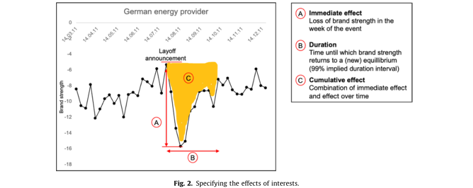

NOTE: figure/graphic rendered as an image from the PDF; its content is not machine-readable text. Caption (if any) follows as the next block.

In addition, endogeneity issues may affect the variables in our second-stage analysis. For example, firms may change their advertising communication intensity strategically in anticipation of changes in economic performance (Rubel et al. 2011). To minimize potential endogeneity issues that may arise from advertising communication, we follow extant literature (e.g., Frennea et al. 2019) and measure advertising communication relative to the industry. The share of spending is set exogenously and not in anticipation of brand performance outcomes.

In a similar vein, social media communication, PR communication, and communication of CSR initiatives might be prone to endogeneity issues, as they can be initiated strategically. For these variables, we use a two-stage control function approach (Wooldridge 2015). In the first stage, we predict social media communication, PR communication, and communication of CSR initiatives based on instrumental variables. Specifically, to predict social media and PR communication, we follow Stäbler and Fischer (2020) and use temporal patterns such as periods of winter and summer sales, the Christmas period, global sporting events, and the largest international trade fairs because they may generate news about promotional activities, sponsorships, and new product introductions. We show that these temporal patterns serve as exogenous predictors for social media and PR communication. To predict communication of CSR initiatives, we use the number of CSR initiatives from the previous year—an approach similar to the one that Dinner et al. (2019) use to predict marketing crises. Again, the instrument serves as a strong predictor. We then compute the residuals from our first-stage models and add them to our focal models. We do not find support for endogeneity concerns. We report these estimations in full detail in Web Appendix M, including descriptions of the selection and validity of the instruments.

Fig. 2. Specifying the effects of interests.

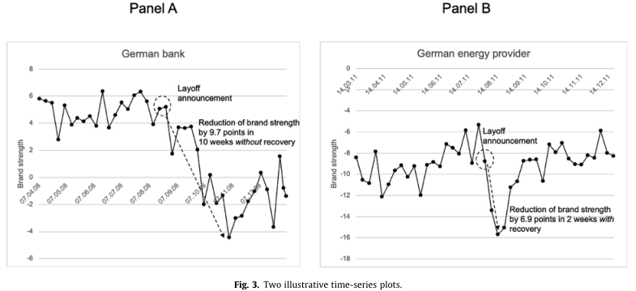

NOTE: figure/graphic rendered as an image from the PDF; its content is not machine-readable text. Caption (if any) follows as the next block.

Fig. 3. Two illustrative time-series plots.

7. Results

7.1. Descriptive statistics and model-free evidence

For our sample of 366 layoff announcements, we have more than 21,000 weekly brand strength observations available. Table 6 (see above) shows the descriptive statistics of our variables. For example, it reveals that the average announced layoff size was 3,083. Of all layoff announcements, 39% were made during the financial crisis (2008–2009), and 34% were reactive. Web Appendix N shows the pairwise correlation coefficients of all variables. To illustrate the potential severity of layoff announcements for brand strength, Fig. 3 presents two examples of time series that show the brand strength development in the 20 weeks before and after a layoff announcement.

In Panel A, the brand strength of a German bank declined by almost 10 index points during the 10 weeks after a large layoff announcement (9,000 jobs cut) and remained at a lower level afterwards. The bank had an above-average advertising communication intensity level, no parallel communication of CSR initiatives and low levels of PR communication activity. In Panel B, the brand strength of a German energy provider declined strongly by 7 points in the two weeks after the minor layoff announcement (500 jobs cut) but recovered rather quickly. The advertising communication intensity of this brand was rather low, the firm did not communicate any CSR initiatives, and it had a moderate level of PR communication activity. In both cases, media coverage was very high.

7.2. Estimation results: First stage

Table 7 presents the parameter estimates of the first-stage analysis. First and most importantly, we find a significantly negative immediate (b = 0.004, p < 0.01) and cumulative effect (b = 0.013, p < 0.01) of layoff announcements on brand strength. In addition, from the estimated cumulative effects and adjustment parameters, we also obtain estimates for the duration of the layoff effects (99% implied duration interval). The brand strength effects last from two weeks to 48 weeks. On average, brands require seven weeks to recover from the brand strength loss.

7.3. Estimation results: Second stage

Table 8 shows the estimated impact of our focal moderating and control variables on the cumulative brand strength effect. We report the estimation results by using the full dataset across all brands and an additional model for those brands for which we also have advertising communication intensity data available. While Table 8 shows the results for the models in which the variables for the different forms of firm communication were aggregated over the time surrounding the layoff announcement, Table 9 illustrates the results of our additional model splitting our focal variables into pre-layoff, during, and post-layoff periods.<sup>3</sup> None of these models causes multicollinearity issues (all variance inflation factors are below 10), and all models show generally consistent results. We find statistically significant effects for all our focal moderators. In support of H2, advertising communication intensity has an overall negative impact on brand strength (Table 8: d = 1.089, p < 0.1). As Table 9 indicates, this effect is ubiquitous and severe for advertising conducted in the event week itself (d = 1.035, p < 0.05) and the week before the layoff (d = 0.951, p < 0.1). In the post-layoff period, we do not find a significant effect. We also find support for H3, as the moderating effect for social media communication via brand-initiated tweets is significantly negative (Table 8: d = 0.012, p < 0.05). Again, we do not find differences among the pre-layoff (d = 0.014, p < 0.05), during (d = 0.017, p < 0.10), and post-layoff (d = 0.013, p < 0.05) periods, as Table 9 indicates. The moderating effect of PR communication is significantly positive (Table 8: d = 0.038, p < 0.05), consistent with H4. As Table 9 indicates, this applies to the pre-layoff (d = 0.037,

Table 7 Main effects of layoff announcements on brand strength.

[output not shown]

NOTE: table converted from PDF layout to HTML text; cell boundaries are reconstructed. See PDF if exact alignment matters.

Notes: * p < 0.10, ** p < 0.05, *** p < 0.01.

3 We estimated models for each time frame separately. An alternative would be to estimate a model that considers all time frames (e.g., pre-, during, and post-advertising) in one model. However, such a model causes severe collinearity issues (variance inflation factors greater than 10), although it still supports our qualitative conclusions (see Web Appendix O).

Table 8 Moderators of the negative impact on brand strength (aggregated measure across time frames).

[output not shown]

NOTE: table converted from PDF layout to HTML text; cell boundaries are reconstructed. See PDF if exact alignment matters.

Notes: * p < 0.10, ** p < 0.05, *** p < 0.01 (one-sided test for directional hypotheses, two-sided test otherwise). a We consider two variables to measure layoff size. The first variable measures the number of employees that are being laid off. Technically, this variable consists of a ‘‘0<sup>00</sup> if the number of employees was not easily accessible for the consumer (e.g., mentioned in the news article). The second variable, however, identifies whether the information is accessible for the consumer (= our dummy variable). Consequently, the heterogeneity is fully captured by the dummy variable, indicating that this information was not visible for consumers. The same argumentation applies to the variable strategic motive. We run robustness checks on a subsample for only the cases for which all information was available. b Reference for the advertising model, as we did not have advertising data for firms in the nondurable goods industry.

Table 9

Moderators of the negative impact on brand strength (individual measures per time frame).

[output not shown]

NOTE: table converted from PDF layout to HTML text; cell boundaries are reconstructed. See PDF if exact alignment matters.

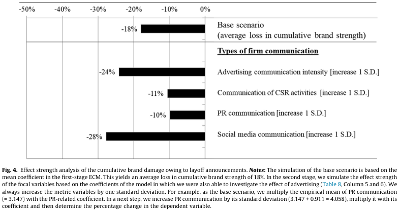

NOTE: figure/graphic rendered as an image from the PDF; its content is not machine-readable text. Caption (if any) follows as the next block.

7.4. Robustness checks

We conducted several robustness checks. First, we tested alternative model specifications of our focal second-stage analysis. For example, instead of brand-specific random effects, we included brand-specific fixed effects. The results do not lead to any other conclusions. Second, we ran a wide range of models varying the sample composition. First, we included only the strongest 50% of corporate brands (based on brand strength). The intuition is that newspapers are more likely to cover strong brands (Stäbler & Fischer 2020). Second, we ran the analyses for a sample of layoff events for which no financial news was communicated at the same time (46% of the sample). Third, we ran the analyses for subsamples and remove layoff events for which we had, for example, missing layoff size information (10% of the sample). While all of these efforts reduced the sample size considerably, the results are still robust and lead to similar conclusions. None of the coefficients switched signs, and most are still significant (see Web Appendix P).

7.5. Practical effect sizes

Fig. 4 presents an effect strength analysis in which the brand strength effects of the focal types of firm communication are simulated. In the base scenario, derived from the mean coefficient in the first stage of the ECM, cumulative brand strength decreases by 18%. To put this percentage value into perspective, we refer to the average, generalizable firm-value elasticity of 0.33, identified for brand-related assets in the broad meta-analysis by Edeling and Fischer (2016). An average announcement would be associated with a firm-value decrease of 18% x 0.33 = 5.94%. Taking the mean total market capitalization of the S&P 500 as of March 31, 2023, i.e., $71.823 billion (S&P Global 2023), we arrive at a value loss of $4.266 billion. The bottom line is that layoff announcements can lead to substantial economic losses incurred through brand strength transgressions.

Fig. 4 shows how firms can apply the different forms of firm communication to weaken these brand strength deteriorations. Our findings indicate that managers should be more reserved with respect to advertising communication intensity (increase from 18% to 24%). During layoffs, they should make use of communicating CSR initiatives (reduction from 18% to 11%) and PR communication such as new product introductions (reduction from 18% to 10%). Finally, the use of social media communication via brand-initiated tweets leads to an increase of brand strength loss (increase from 18% to 28%).

8. Discussion

8.1. Research implications

Layoffs are a highly relevant and frequently applied strategic management instrument. Layoff decisions are regularly triggered by stagnating market demand or industry-wide economic effects and aim to improve future firm performance. However, researchers have only recently started to examine the impact of layoffs on consumer perceptions (e.g., Landsman & Stremersch 2020). By focusing on brand strength as the outcome variable and on the firm communication surrounding layoff

Fig. 4. Effect strength analysis of the cumulative brand damage owing to layoff announcements. Notes: The simulation of the base scenario is based on the mean coefficient in the first-stage ECM. This yields an average loss in cumulative brand strength of 18%. In the second stage, we simulate the effect strength of the focal variables based on the coefficients of the model in which we were also able to investigate the effect of advertising (Table 8, Column 5 and 6). We always increase the metric variables by one standard deviation. For example, as the base scenario, we multiply the empirical mean of PR communication (= 3.147) with the PR-related coefficient. In a next step, we increase PR communication by its standard deviation (3.147 + 0.911 = 4.058), multiply it with its coefficient and then determine the percentage change in the dependent variable.

announcements, we can shed light on consumers’ responses to layoff announcements and to firms’ communication decisions in this context.

Our findings regarding the main effect of layoff announcements on cumulative brand strength indicate that consumers care about layoffs, even though they are not directly affected by these decisions. Downsizing has no effect on customer satisfaction if consumers rely on brands as the primary cue in purchasing decisions (Habel & Klarmann 2015). However, we demonstrate that although downsizing may have no impact on customer satisfaction, it does affect brand perception. Thus, our research provides a new link between a strategic management decision (i.e., layoffs) and a core marketing metric—brand strength—that is among a firm’s most important intangible assets.

Our findings contribute to the research aiming to identify the hidden costs of layoffs (Williams et al. 2011), which represent a loss in brand equity that was built by marketing investments. The negative impact on brand strength seems to be a cost of downsizing that researchers and managers have overlooked and that has negative consequences for future revenues (Landsman & Stremersch 2020). Hence, our results may explain why layoffs often do not lead to the expected results.

Our study is the first to investigate the moderating impact of different types of firm communication on brand strength surrounding layoff announcements. We derive several theoretical implications from these results. First, we differentiate different types of firm communication according to a wide range of attributes. We highlight the importance of connecting these attributes to the situation a company is facing. Attributes that are considered positive under ‘‘normal” circumstances can have negative effects in the context of corporate decisions that are legally acceptable but ethically questionable. For example, in contrast to previous literature emphasizing the positive brand effects of being entertaining (e.g., Rosengren et al. 2020), we show that being entertaining—an attribute closely related to advertising communication intensity—increases the loss in brand strength in the context of layoff announcements.

Second, our results add to the findings of Landsman and Stremersch (2020). They show that after layoffs, firms experience adverse changes in sales. They ask for further research that analyzes consumers’ responses to firms’ marketing mix decisions in the context of layoff announcements. We derive a negative layoff announcement–brand strength relationship that may partially explain their derived adverse changes in sales. Landsman and Stremersch (2020) further show that advertising elasticity with respect to sales decreases after layoffs. We find that advertising communication intensity even harms brand strength in the wake of layoff announcements. Thus, our conclusion with respect to advertising communication intensity differs from theirs: Whereas they suggest increasing advertising investments after the announcement ‘‘as long as advertising elasticity remains positive” (p. 138), we suggest marketers concerned about the firm’s brand strength should shift budgets away from advertising communication to types of firm communication that are perceived as less costly and more trustworthy (e.g., PR communication).

Third, consumers appear to appreciate firms’ maintenance of their investments in another important stakeholder group, society in general, despite the economic pressure that led to the layoff decision. This positive moderating effect of communication of CSR initiatives is consistent with earlier work finding that consumers attribute less blame to firms with strong CSR initiatives that suffer from a product-harm crisis (Klein & Dawar 2004). Importantly, the effect is also congruent with prior findings that only CSR initiatives in domains other than initial corporate social irresponsibility (to which ‘‘workforce reductions” belong) have a firm value-enhancing effect (Lenz et al. 2017).

Fourth, our work shows that pre-layoff brand strength serves to buffer the impact of negative consumer perceptions. This aligns with other studies by brand academics that have shown that brand strength protects a firm from the adverse effects of crises triggered by product safety incidents (e.g., Ahluwalia et al. 2000). Thus, our results support the idea that brand equity is a rather ‘‘sticky” construct (Hanssens et al. 2014) that, after being built up over time, does not depreciate quickly.

Finally, our study extends earlier research methodologically, as we are the first to estimate the cumulative effects of layoff announcements. A comparison of the brand strength recovery time from the announcement with other types of brand crises (product harm and corporate social irresponsibility) shows that the maximum (48 weeks vs. 9.5 months) and mean durations (7 weeks vs. 2.6 months) are comparable (Backhaus & Fischer 2016), further demonstrating the relevance of layoff announcements for marketing research.

8.2. Managerial implications

8.2.1. Actionable implications for firm communication surrounding layoff announcements Our results offer managers practical guidance for how to better align their decisions regarding firm communication in the context of layoff announcements.

With respect to advertising communication intensity and social media communication via brand-initiated tweets, companies should be more restrained. Prior research has shown (Hansen et al. 2018) that crisis events may lead to negative online firestorms that amplify the negative consequences for brand perception. Firms could strategically lower the amount of social media communication via brand-initiated tweets before, during, and after layoff announcements to limit the chance that consumers use these tweets as triggers to complain about these workforce reductions.

Similarly, as advertising communication intensity hurts brand strength in the wake of layoff announcements, firms should avoid extensive investment in advertising in this context. Consumers might perceive advertising communication as entertainment-related and cost-generating, which could be evaluated as inappropriate in the context of layoff announcements. While we cannot make specific recommendations on advertising communication content, the attributes (e.g., entertainment value) in our theoretical framework suggest that post-layoff companies should change the content of their

advertising communication and move away from entertainment-related to more information-related content. However, while advertising communication intensity hurts before and during the layoff announcement, we do not find an effect of advertising communication intensity after the event. In fact, post-crisis advertising communication may help in the long run in the context of product-harm crises (Cleeren et al. 2013). We show that increasing advertising communication intensity after the layoff announcement at least does not hurt and may help rebuild the brand in the long run.

Should firms be more reserved regarding other forms of firm communication? No—with respect to PR communication and the communication of CSR initiatives, companies should stay active. When confronted with layoff scenarios, companies should consider the strategic launch of other neutral or positive brand news, such as communication of CSR initiatives or PR communication that relates to the marketing mix. These types of firm communication seem to be appropriate measures to restore trust. This recommendation is supported by Stäbler and Fischer (2020), who argue that firms may diminish the negative consequences of crisis events caused by ethical misbehavior if they launch brand-related news.

The effects of the control variables also provide actionable implications. Firms are well advised to invest in their brands continuously, as a strong brand strength acts as a buffer against negative consumer brand perceptions after layoff announcements. Media coverage is the most powerful lever in terms of effect strength (increasing media coverage by one S.D. leads to a 34% brand strength loss). Stäbler and Fischer (2020) provide managers with guidelines for limiting media coverage in the case of CSI events, many of which might be transferrable to the layoff context.

8.2.2. Implications regarding marketing’s seat at the executive table Our results also underscore the need for marketing executives to have a seat on executive boards. While marketing mix activities seem unrelated to layoff decisions, our study demonstrates that consumers connect layoff announcements with advertising communication intensity, social media communication, PR communication, and the communication of CSR initiatives. Marketing managers need to create awareness that seemingly unrelated company decisions such as layoffs are also relevant for communication that is initiated by marketing. Consequently, layoff events need to be better planned strategically. For example, top executive managers could better align their decisions internally across different functional departments (e.g., executive board, strategy, finance, marketing, PR). This alignment is especially important in an increasingly complex world in which the interests of several stakeholder groups must be given equal consideration. The Business Roundtable (2019) decision to move away from the idea of pure shareholder value is emblematic of this evolution.

8.2.3. Implications for internal brand perception monitoring Our results underscore the usefulness of disaggregated consumer mindset metrics for precisely attributing the effect of nonmarketing-related firm actions on consumer perceptions. Market research companies such as YouGov or Morning Consult have recently begun to collect, track, and process such data frequently (e.g., daily). They overcome the main limitation of more aggregated consumer mindset metrics from providers such as ACSI or Young & Rubicam (yearly collection), where an unequivocal brand-perception attribution of events such as layoff announcements is not possible. Managers should be encouraged to use these new data, as this information can serve as a useful early warning for changes in the brand and the financial performance of firms.

8.3. Limitations and avenues for further research

Our study has some limitations. First, our sample covers firms that are contained in the YouGov database, subjecting this study to the inclusion requirements of the YouGov database. Nevertheless, our robustness checks indicate that our results hold if we vary the sample composition.

Second, it could be worthwhile to intensify the analysis of the effect of layoff announcements on online word of mouth. Our preliminary analysis of 2020 layoff announcements (Pre-study 3, Section 4) shows that in recent times, Twitter and Facebook users tend to pick up such news. Future research could track the volume and valence of layoff-related online word of mouth, as in work on product recalls (Borah & Tellis 2016). Alternatively, studies could apply the novel social media-based brand reputation tracker (Rust et al. 2021) to see whether our findings, which rely on a rather traditional survey approach, hold for unstructured textual data.

Finally, we highlighted that layoffs can be regarded as a strategic, non-marketing-related firm decision, similar to tax evasion and avoidance, corporate sociopolitical activism, and lobbying. Future research could integrate all these events and investigate which of them affect brand strength the most and how the impact of different types of firm communication differs across them.

Data availability

The authors do not have permission to share data.

Declaration of Competing Interest

The authors declare that they have no known competing financial interests or personal relationships that could have appeared to influence the work reported in this paper.

Acknowledgments

We thank YouGov for providing access to their BrandIndex database and Ebiquity for providing data on advertising. We also thank Martin Klarmann, Franziska Völckner, Marnik G. Dekimpe, and Werner J. Reinartz for insightful comments on earlier versions of the article.

Appendix A. Supplementary material

Supplementary data to this article can be found online at https://doi.org/10.1016/j.ijresmar.2023.06.002.

References

Aggarwal, P. (2004). The effects of brand relationship norms on consumer attitudes and behavior. Journal of Consumer Research, 31(1), 87–101. Ahluwalia, R., Burnkrant, R. E., & Unnava, H. R. (2000). Consumer response to negative publicity: The moderating role of commitment. Journal of Marketing

Research, 37(2), 203–214. Anaza, N. A., Saavedra, J. L., Hair, J. F., Jr, Bagherzadeh, R., Rawal, M., & Osakwe, C. N. (2021). Customer-brand disidentification: Conceptualization, scale

development and validation. Journal of Business Research, 133, 116–131. Backhaus, M., & Fischer, M. (2016). Brand damage from product harm and corporate social irresponsi-bility: How deep and how long. Marketing Science

Institute Working Paper Series, 16(133), 1–63. Barnett, M. L., & Salomon, R. M. (2012). Does it pay to be really good? Addressing the shape of the relationship between social and financial performance.

Strategic Management Journal, 33(11), 1304–1320. Batra, R., & Keller, K. L. (2016). Integrating marketing communications: New findings, new lessons, and new ideas. Journal of Marketing, 80(6), 122–145. Berger, J., & Milkman, K. L. (2012). What makes online content viral? Journal of Marketing Research, 49(2), 192–205. Bhattarcharya, C. B., & Sen, S. (2003). Consumer-company identification: A framework for understanding consumers’ relationships with companies. Journal

of Marketing, 76(2), 76–88. Bidwell, M., & Capelli, P. (2016). How layoffs hurt companies. Retrieved from https://knowledge.wharton.upenn.edu/article/how-layoffs-cost-companies/.

Accessed April 12, 2023. Bloomberg (2020). IBM planning 10,000 job cuts in Europe Ahead of unit sale. Retrieved from https://www.bloomberg.com/news/articles/2020-11-25/ibm-

planning-about-10-000-job-cuts-in-europe-ahead-of-unit-sale. Accessed April 12, 2023. Borah, A., & Tellis, G. J. (2016). Halo (spillover) effects in social media: Do product recalls of one brand hurt or help rival brands? Journal of Marketing

Research, 53(2), 143–160. Brown, T. J., & Dacin, P. A. (1997). The company and the product: Corporate associations and consumer product responses. Journal of Marketing, 61(1), 68–84. Business Roundtable (2019). Business roundtable redefines the purpose of a corporation to promote ‘an economy that serves all Americans’. Retrieved from

https://www.businessroundtable.org/business-roundtable-redefines-the-purpose-of-a-corporation-to-promote-an-economy-that-serves-allamericans. Accessed April 12, 2021. Chen, P., Mehrotra, V., Sivakumar, R., & Yu, W. W. (2001). Layoffs, shareholders’ wealth, and corporate performance. Journal of Empirical Finance, 8(2),

171–199. Cleeren, K., Van Heerde, H. J., & Dekimpe, M. G. (2013). Rising from the ashes: How brands and categories can overcome product-harm crises. Journal of

Marketing, 77(2), 58–77. Colicev, A., Malshe, A., Pauwels, K., & O’Connor, P. (2018). Improving consumer mindset metrics and shareholder value through social media: The different

roles of owned and earned media. Journal of Marketing, 82(1), 37–56. Danaher, P., & Rossiter, J. R. (2011). Comparing perceptions of marketing communication channels. European Journal of Marketing, 45(1/2), 6–42. Darby, M. R., & Karni, E. (1973). Free competition and the optimal amount of fraud. The Journal of Law and Economics, 16(1), 67–88. Datta, D. K., Guthrie, J. P., Basuil, D., & Pandey, A. (2010). Causes and effects of employee downsizing: A review and synthesis. Journal of Management, 36(1),

281–348. Datta, H., Ailawadi, K. L., & Van Heerde, H. J. (2017). How well does consumer-based brand equity align with sales-based brand equity and marketing-mix

response? Journal of Marketing, 81(3), 1–20. Datta, H., Van Heerde, H. J., Dekimpe, M. G., & Steenkamp, J. B. E. (2022). Cross-national differences in market response: Line-length, price, and distribution

elasticities in 14 Indo-Pacific rim economies. Journal of Marketing Research, 59(2), 251–270. De Meuse, K. P., Bergmann, T. J., Vanderheiden, P. A., & Roraff, C. E. (2004). New evidence regarding organizational downsizing and a firm’s financial

performance: A long-term analysis. Journal of Managerial Issues, 16(2), 155–177. Dijkstra, M., Buijtels, H. E., & Van Raaij, W. F. (2005). Separate and joint effects of medium type on consumer responses: A comparison of television, print,

and the Internet. Journal of Business Research, 58(3), 377–386. Dinner, I. M., Kushwaha, T., & Steenkamp, J. B. E. (2019). Psychic distance and performance of MNCs during marketing crises. Journal of International Business

Studies, 50(3), 339–364. Edeling, A., & Fischer, M. (2016). Marketing’s impact on firm value: Generalizations from a meta-analysis. Journal of Marketing Research, 53(4), 515–534. Ettenson, R., & Knowles, J. (2008). Don’t confuse reputation with brand. MIT Sloan Management Review, 49(2), 19–21. Euronews (2020). Coronavirus job cuts: Which companies in Europe are slashing their workforces because of covid-19? Retrieved from https://www.

euronews.com/2020/07/24/coronavirus-job-cuts-which-companies-in-europe-are-slashing-their-workforces-because-of-co. Accessed April 12, 2023. Fischer, M., Völckner, F., & Sattler, H. (2010). How important are brands? A cross-category, cross-country study. Journal of Marketing Research, 47(5),

823–839. Flanagan, D. J., & O’Shaughnessy, K. C. (2005). The effect of layoffs on firm reputation. Journal of Management, 31(3), 445–463. Fombrun, C., & Shanley, M. (1990). What’s in a name? Reputation building and corporate strategy. Academy of management Journal, 33(2), 233–258. Freeman, S. J., & Cameron, K. S. (1993). Organizational downsizing: A convergence and reorientation framework. Organization Science, 4, 10–29. Frennea, C., Han, K., & Mittal, V. (2019). Value appropriation and firm shareholder value: Role of advertising and receivables management. Journal of

Marketing Research, 56(2), 291–309. Gijsenberg, M. J. (2014). Going for gold: Investigating the (non) sense of increased advertising around major sports events. International Journal of Research in

Marketing, 31(1), 2–15.

Gijsenberg, M. J., Van Heerde, H. J., & Verhoef, P. C. (2015). Losses loom longer than gains: Modeling the impact of service crises on perceived service quality

over time. Journal of Marketing Research, 52(5), 642–656. Golder, P. N., Dekimpe, M. G., An, J. T., van Heerde, H. J., Kim, D. S. U., & Alba, J. W. (2022). Learning from Data: An Empirics-First Approach to Relevant

Knowledge Generation. Journal of Marketing (online). Habel, J., & Klarmann, M. (2015). Customer reactions to downsizing: When and how is satisfaction affected? Journal of the Academy of Marketing Science, 43

(6), 768–789. Hansen, N., Kupfer, A. K., & Hennig-Thurau, T. (2018). Brand crises in the digital age: The short-and long-term effects of social media firestorms on

consumers and brands. International Journal of Research in Marketing, 35(4), 557–574. Hanssens, D. M., Pauwels, K. H., Srinivasan, S., Vanhuele, M., & Yildirim, G. (2014). Consumer attitude metrics for guiding marketing mix decisions. Marketing

Science, 33(4), 534–550. Heider, F. (1958). The psychology of interpersonal relations. New York: John Wiley & Sons. Himme, A., & Fischer, M. (2014). Drivers of the cost of capital: The joint role of non-financial metrics. International Journal of Research in Marketing, 31(2),

224–238. Homburg, C., Klarmann, M., & Staritz, S. (2012). Customer uncertainty following downsizing: The effects of extent of downsizing and open communication.

Journal of Marketing, 76(3), 112–129. Homer, P. M. (1995). Ad size as an indicator of perceived advertising costs and effort: The effects on memory and perceptions. Journal of Advertising, 24(4),

1–12. Jin, H. (2022). Exclusive: Elon Musk wants to cut 10% of Tesla jobs. Retrieved from https://www.reuters.com/technology/exclusive-musk-says-tesla-needs-cut-

staff-by-10-pauses-all-hiring-2022-06-03/. Accessed April 12, 2023. Kahneman, D., Knetsch, J. L., & Thaler, R. H. (1986). Fairness and the assumptions of economics. Journal of Business, 59(4), 285–300. Katz, E., Haas, H., & Gurevitch, M. (1973). On the use of the mass media for important things. American Sociological Review, 38(April), 164–181. Keller, K. L. (1993). Conceptualizing, measuring, and managing customer-based brand equity. Journal of Marketing, 57(1), 1–22. Keller, K. L. (2001). Mastering the marketing communications mix: Micro and macro perspectives on integrated marketing communication programs.

Journal of Marketing Management, 17(7–8), 819–847. Keller, K. L. (2008). Strategic brand management (3rd ed.). Englewood Cliffs: Prentice Hall. Khamitov, M., Grégoire, Y., & Suri, A. (2020). A systematic review of brand transgression, service failure recovery and product-harm crisis: Integration and

guiding insights. Journal of the Academy of Marketing Science, 48(3), 519–542. Köhler, C., Mantrala, M. K., Albers, S., & Kanuri, V. K. (2017). A meta-analysis of marketing communication carryover effects. Journal of Marketing Research, 54

(6), 990–1008. Kirmani, A. (1990). The effect of perceived advertising costs on brand perceptions. Journal of Consumer Research, 17(2), 160–171. Kirmani, A., & Wright, P. (1989). Money talks: Perceived advertising expense and expected product quality. Journal of Consumer Research, 16(3), 344–353. Klein, J. G., Smith, N. C., & John, A. (2004). Why we boycott: Consumer motivations for boycott participation. Journal of Marketing, 68(3), 92–109. Klein, J., & Dawar, N. (2004). Corporate social responsibility and consumers’ attributions and brand evaluations in a product–harm crisis. International

Journal of Research in Marketing, 21(3), 203–217. Kotler, P., & Keller, K. L. (2015). Marketing management (15th ed.). Essex: Pearson Higher Ed.. Kotler, P., & Mindak, W. (1978). Marketing and public relations: Should they be partners or rivals? Journal of Marketing, 42(4), 13–20. Kronrod, A., & Huber, J. (2019). Ad wearout wearout: How time can reverse the negative effect of frequent advertising repetition on brand preference.

International Journal of Research in Marketing, 36(2), 306–324. Landsman, V., & Stremersch, S. (2020). The commercial consequences of collective layoffs: Close the plant, lose the brand? Journal of Marketing, 84(3),

122–141. Lenz, I., Wetzel, H. A., & Hammerschmidt, M. (2017). Can doing good lead to doing poorly? Firm value implications of CSR in the face of CSI. Journal of the

Academy of Marketing Science, 45(5), 677–697. Lewin, J. E. (2009). Business customers’ satisfaction: What happens when suppliers downsize? Industrial Marketing Management, 38(3), 283–299. Lewin, J. E., & Johnston, W. J. (2008). The impact of supplier downsizing on performance, satisfaction over time, and repurchase intentions. Journal of Business

& Industrial Marketing, 23(4), 249–255. Liu, Y., & Shankar, V. (2015). The dynamic impact of product-harm crises on brand preference and advertising effectiveness: An empirical analysis of the

automobile industry. Management Science, 61(10), 2514–2535. Love, E. G., & Kraatz, M. (2009). Character, conformity, or the bottom line? How and why downsizing affected corporate reputation. Academy of Management

Journal, 52(2), 314–335. Luo, X., Raithel, S., & Wiles, M. A. (2013). The impact of brand rating dispersion on firm value. Journal of Marketing Research, 50(3), 399–415. Layoffs.fyi (2023), Layoffs tracker. Retrieved from https://layoffs.fyi/. Accessed March 31 2023. New York Times (2008). Nokia to shut German plant. Retrieved from https://www.nytimes.com/2008/01/15/technology/15iht-nokia.4.9235958.html.

Accessed April 12, 2023. Nielsen (2015). Global trust in advertising. Retrieved from https://www.nielsen.com/insights/2015/global-trust-in-advertising-2015/. Accessed April 12, 2023. Panagopoulos, N. G., Mullins, R., & Avramidis, P. (2018). Sales force downsizing and firm-idiosyncratic risk: The contingent role of investors’ screening and

firm’s signaling processes. Journal of Marketing, 82(6), 71–88. Pavlou, P. A., & Gefen, D. (2005). Psychological contract violation in online marketplaces: Antecedents, consequences, and moderating role. Information

Systems Research, 16(4), 372–399. Rosengren, S., Eisend, M., Koslow, S., & Dahlen, M. (2020). A meta-analysis of when and how advertising creativity works. Journal of Marketing, 84(6), 39–56. Rosenthal, R. (1991). Meta-analytic procedures for social science research (2nd ed.). Newbury Park, CA: Sage. Rubel, O., Naik, P. A., & Srinivasan, S. (2011). Optimal advertising when envisioning a product-harm crisis. Marketing Science, 30(6), 1048–1065. Rust, R. T., Rand, W., Huang, M.-H., Stephen, A. T., Brooks, G., & Chabuk, T. (2021). Real-time brand reputation tracking using social media. Journal of

Marketing, 85(4), 21–43. S&P Global (2023). S&P 500. Retrieved from https://www.spglobal.com/spdji/en/indices/equity/sp-500/#overview. Accessed April 12, 2023. Sen, S., & Bhattacharya, C. B. (2001). Does doing good always lead to doing better? Consumer reactions to corporate social responsibility. Journal of Marketing

Research, 38(2), 225–243. Sethuraman, R., Tellis, G. J., & Briesch, R. A. (2011). How well does advertising work? Generalizations from a meta-analysis of brand advertising elasticities.

Journal of Marketing Research, 48(3), 457–471. Shen, Q., & Villas-Boas, J. M. (2018). Behavior-based advertising. Management Science, 64(5), 2047–2064. Shimp, T. A., & Sharma, S. (1987). Consumer ethnocentrism: Construction and validation of the CETSCALE. Journal of Marketing Research, 24(3), 280–289. Skarlicki, D. P., Ellard, J. H., & Kelln, B. R. C. (1998). Third-party perceptions of a layoff: Procedural, derogation, and retributive aspects of justice. Journal of

Applied Psychology, 83(1), 119–127. Sorescu, A., Warren, N. L., & Ertekin, L. (2017). Event study methodology in the marketing literature: An overview. Journal of the Academy of Marketing

Science, 45(1), 186–207. Stäbler, S., & Fischer, M. (2020). When does corporate social irresponsibility become news? Evidence from more than 1,000 brand transgressions across five

countries. Journal of Marketing, 84(3), 46–67. Subramony, M., & Holtom, B. C. (2012). The long-term influence of service employee attrition on customer outcomes and profits. Journal of Service Research,

15(4), 460–473. Sucher, S. J., & Gupta, S. (2018). Layoffs that don’t break your company. Harvard Business Review, 96(3), 122–129.

Thomas, J. S., & Sullivan, U. Y. (2005). Managing marketing communications with multichannel customers. Journal of Marketing, 69(4), 239–251. Van Heerde, H. J., Gijsenberg, M., Dekimpe, M. G., & Steenkamp, J. B. E. (2013). Price and advertising effectiveness over the business cycle. Journal of

Marketing Research, 50(2), 177–193. Van Heerde, H. J., Helsen, K., & Dekimpe, M. G. (2007). The impact of a product-harm crisis on marketing effectiveness. Marketing Science, 26(2), 230–245. Williams, P., Khan, M. S., & Naumann, E. (2011). Customer dissatisfaction and defection: The hidden costs of downsizing. Industrial Marketing Management,

40(3), 405–413. Wooldridge, J. M. (2015). Control function methods in applied econometrics. The Journal of Human Resources, 50(2), 420–445. Zyglidopoulos, S. (2005). The impact of downsizing on corporate reputation. British Journal of Management, 16, 253–259.